# Marketing Report BWIN

Sébastien PAVOT / Alejandro LOPEZ / DINU WIJAYAWEERA

1/7/2020

This marketing report and manual was done using RMarkDown. It’s an automatic report that will change every time the data is updated.

In this report, you will first find some insights about the datamart created and then you will find an appendix with all variables of the datamart and a short explanation.

### This graphs show you the age distribution of the customers of BWIN:

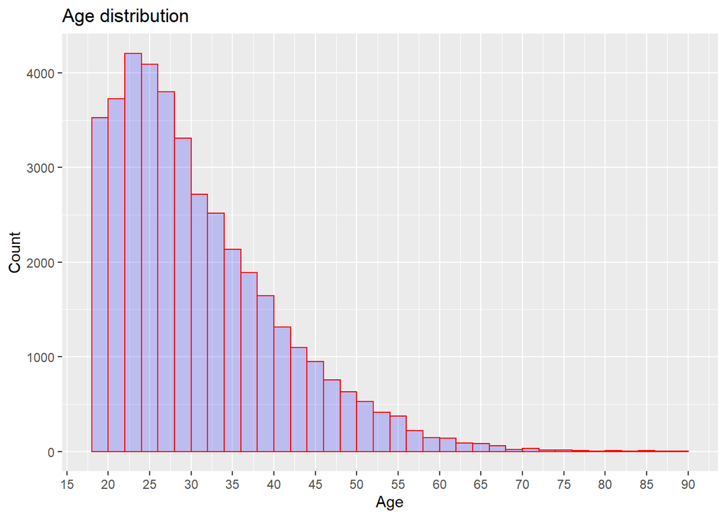

For the three tables bellow, they contains information about users regarding their country or their languages.

#### About the variables, here is a short description of each:

- Total_Gains: is the actual money generated. Note that if the number is negative, it’s meaning that the users lost more than they won so it is profitable for the company.
- Avg_BetsPerDay is equal to the average of a number bets per day done by a user
- Age is the average age of the users
- Avg_TotalBets is the average amount bet by users
- Avg_PokerBalance is the average balance of pokers players
- Avg_Poker_Transaction is the average number of transactions done by poker players wether it’s a sell or a buy transaction. *Nb_Users is equal to the number of users.

### Top 5 countries which are bringing the most revenue regardings Gains with at least 500 users

| CountryName | Total_Gains | Avg_BetsPerDay | Age | Avg_TotalBets | Avg_Poker_Balance | Avg_Poker_Transcation | Nb_Users |
| --- | --- | --- | --- | --- | --- | --- | --- |
| Germany | -3668592 | 4.82 | 31 | 165.71 | 4.35 | 0.94 | 24146 |
| Greece | -882130 | 17.79 | 31 | 264.07 | 26.41 | 4.63 | 2379 |
| Spain | -668123 | 11.54 | 29 | 166.61 | 18.90 | 5.67 | 2395 |
| Austria | -555155 | 27.32 | 29 | 110.14 | 53.75 | 10.74 | 1451 |
| France | -486745 | 12.74 | 29 | 172.97 | 22.68 | 11.36 | 2069 |

### Top 5 countries which are bringing the less revenue regardings Gains with at least 500 users

| CountryName | Total_Gains | Avg_BetsPerDay | Age | Avg_TotalBets | Avg_Poker_Balance | Avg_Poker_Transcation | Nb_Users |
| --- | --- | --- | --- | --- | --- | --- | --- |
| Poland | -220553 | 6.24 | 28 | 135.92 | 1.88 | 4.27 | 2411 |
| Switzerland | -229369 | 16.34 | 30 | 260.24 | 49.28 | 13.25 | 577 |
| Denmark | -266561 | 18.21 | 26 | 72.64 | 53.97 | 55.79 | 1584 |
| Turkey | -356943 | 13.49 | 26 | 106.77 | 12.71 | 2.92 | 2461 |
| Italy | -437177 | 21.76 | 32 | 167.26 | 48.86 | 12.22 | 1000 |

### Top 5 most popular languages per number of users:

| Language Description | Nb_Users | Total_Gains | Avg_BetsPerDay | Age | Avg_TotalBets | Avg_Poker_Balance | Avg_Poker_Transcation |
| --- | --- | --- | --- | --- | --- | --- | --- |
| German | 26177 | -4429058 | 6.34 | 31 | 165.30 | 9.48 | 1.64 |
| Turkish | 2448 | -365715 | 13.64 | 26 | 107.27 | 14.04 | 2.93 |
| Greek | 2425 | -897341 | 17.41 | 31 | 255.13 | 24.57 | 4.40 |
| Polish | 2226 | -227810 | 5.73 | 28 | 145.81 | 1.90 | 4.58 |
| Spanish | 2207 | -615851 | 11.57 | 29 | 165.06 | 16.28 | 5.95 |

### Stakes amount spend per day over all the users:

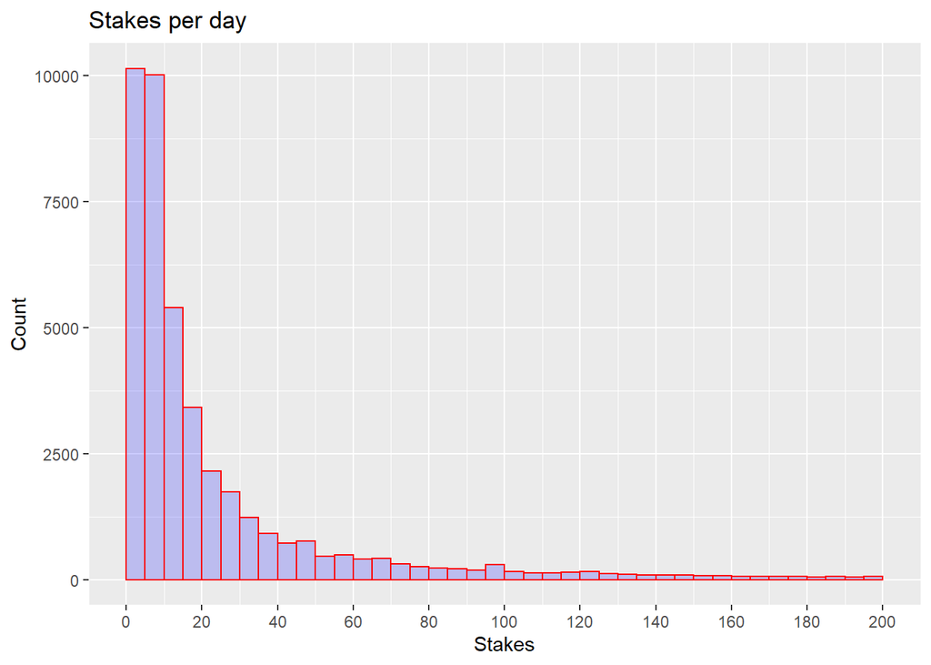

### Most comon application sources by number of applicants & most profitable sources:

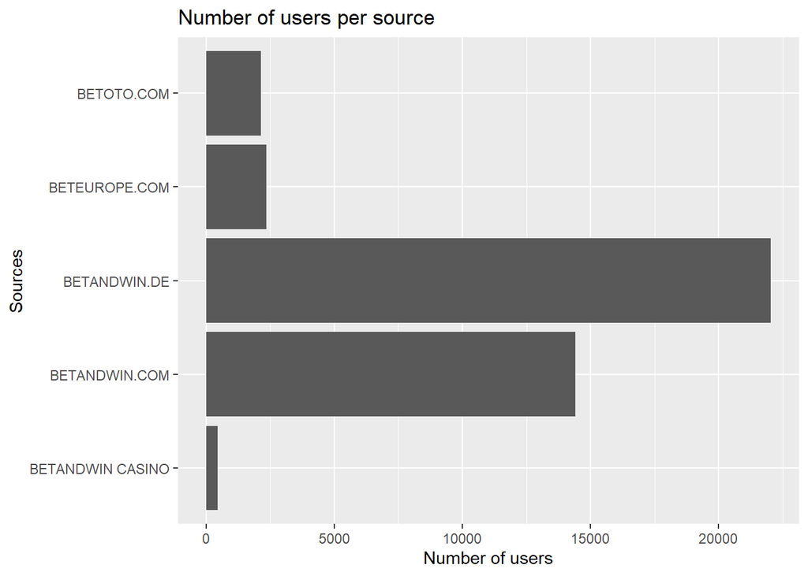

### Most profitable sources per user:

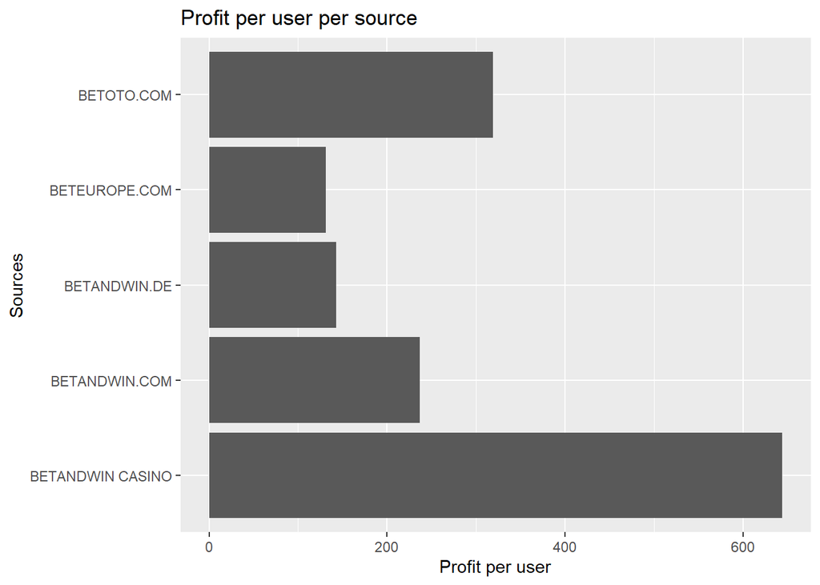

We’ve now reached the end of the report part of this document, bellow you will find a table containing all the variables of the datamart and a short description for each.

### Datamart & variables description:

The datamart was created by merging 4 differents files: Demographics, UserDailyAggregation, PokerChipConversions and ActualSportsGambling. This datamart is a user centric datamart so you will find in this one line per UserID.

| Name of the variable | Description |
| --- | --- |
| UserID | Unique User Identification Number |
| GainsPerDay | Average Winnings - Average Stakes by customer |
| WinningsPerDay | Average Winnings by customer |
| StakePerDay | Average Stakes by customer |
| OverallGains | Total Winnings - Total Stakes by customer |
| BetsPerDay | Average Bet by customer |
| StakesPerBet | Average Stake / Average Bet by customer |
| TotalNumberofBets | Total Bets by customer |
| Product_Percentage1 | Percentage of Bets in Sports Book (fixed-odd) by customer |
| Product_Percentage2 | Percentage of Bets in Sports Book (live-action) by customer |
| Product_Percentage3 | Percentage of Bets in Poker BossMedia by customer |
| Product_Percentage4 | Percentage of Bets in Casino BossMedia by customer |
| Product_Percentage5 | Percentage of Bets in Supertoto by customer |
| Product_Percentage6 | Percentage of Bets in Games VS by customer |
| Product_Percentage7 | Percentage of Bets in Games bwin by customer |
| Product_Percentage8 | Percentage of Bets in Casino Chartwell by customer |
| RegDate | Customer’s Account Creation Date |
| FirstPay | Customer’s first Deposit to Account Date |
| FirstAct | Customer’s first Active Play Date |
| FirstSp | Customer’s first Sports Book Play Date |
| FirstCa | Customer’s first Casino Play Date |
| FirstGa | Customer’s first Games Play Date |
| FirstPo | Customer’s first Poker Play Date |
| Gender | The gender of the customer. |
| AlreadyPlaySportsBook | This variable indicates if the customer plays Sports Book. (The null values in FirstSP date column is presumed to indicate that the customer has not played sports book) |
| AlreadyPlayCasino | This variable indicates if the customer plays Casino. (The null values in FirstCa date column is presumed to indicate that the customer has not played casino) |
| AlreadyPlayGames | This variable indicates if the customer plays Games. (The null values in FirstGa date column is presumed to indicate that the customer has not played games) |
| AlreadyPlayPoker | This variable indicates if the customer plays Poker. (The null values in FirstPo date column is presumed to indicate that the customer has not played Poker) |
| CountryName | Name of the country which the customer is from. |
| Language Description | The name of the language of the property. |

[output cut: 74 more lines]